# Assignment 1 - Data wrangling and functions

September 18, 2026 | 17:59:00 | CEST

```r
# LOAD THE PACKAGES YOU ARE USING IN THIS CODE CHUNK
# library(nameofpackage)

library(tidyverse)
```

## Task 1: Getting started with the Astronaut Database

The data this week comes from [Mariya Stavnichuk and Tatsuya Corlett](https://data.mendeley.com/datasets/86tsnnbv2w/1).

This [article](https://www.sciencedirect.com/science/article/abs/pii/S2214552420300444) talks about the data set in greater detail.

> This database contains publically available information about all astronauts who participated in space missions before 15 January 2020 collected from NASA, Roscosmos, and fun-made websites. The provided information includes full astronaut name, sex, date of birth, nationality, military status, a title and year of a selection program, and information about each mission completed by a particular astronaut such as a year, ascend and descend shuttle names, mission and extravehicular activity (EVAs) durations.

You can use the data set directly by importing the csv file in the repository.

1. How many unique astronauts are stored in the data set?

```r
# YOUR CODE HERE
astronauts <- read_csv("astronauts.csv")
glimpse(astronauts)
```

```
Rows: 1,277
Columns: 23
$ id                       <dbl> 1, 2, 3, 4, 5, 6, 7, 8, 9, 10, 11, 12, 13, 14…
$ number                   <dbl> 1, 2, 3, 3, 4, 5, 5, 6, 6, 7, 7, 7, 8, 8, 9, …
$ nationwide_number        <dbl> 1, 2, 1, 1, 2, 2, 2, 4, 4, 3, 3, 3, 4, 4, 5, …
$ name                     <chr> "Gagarin, Yuri", "Titov, Gherman", "Glenn, Jo…
$ original_name            <chr> "ГАГАРИН Юрий Алексеевич", "ТИТОВ Герман Степ…
$ sex                      <chr> "male", "male", "male", "male", "male", "male…
$ year_of_birth            <dbl> 1934, 1935, 1921, 1921, 1925, 1929, 1929, 193…
$ nationality              <chr> "U.S.S.R/Russia", "U.S.S.R/Russia", "U.S.", "…
$ military_civilian        <chr> "military", "military", "military", "military…
$ selection                <chr> "TsPK-1", "TsPK-1", "NASA Astronaut Group 1",…
$ year_of_selection        <dbl> 1960, 1960, 1959, 1959, 1959, 1960, 1960, 196…
$ mission_number           <dbl> 1, 1, 1, 2, 1, 1, 2, 1, 2, 1, 2, 3, 1, 2, 1, …
$ total_number_of_missions <dbl> 1, 1, 2, 2, 1, 2, 2, 2, 2, 3, 3, 3, 2, 2, 3, …
$ occupation               <chr> "pilot", "pilot", "pilot", "PSP", "Pilot", "p…
$ year_of_mission          <dbl> 1961, 1961, 1962, 1998, 1962, 1962, 1970, 196…
$ mission_title            <chr> "Vostok 1", "Vostok 2", "MA-6", "STS-95", "Me…
$ ascend_shuttle           <chr> "Vostok 1", "Vostok 2", "MA-6", "STS-95", "Me…
$ in_orbit                 <chr> "Vostok 2", "Vostok 2", "MA-6", "STS-95", "Me…
$ descend_shuttle          <chr> "Vostok 3", "Vostok 2", "MA-6", "STS-95", "Me…
$ hours_mission            <dbl> 1.77, 25.00, 5.00, 213.00, 5.00, 94.00, 424.0…
$ field21                  <dbl> 0, 0, 0, 0, 0, 0, 0, 0, 0, 0, 0, 0, 0, 0, 0, …
$ eva_hrs_mission          <dbl> 0.00, 0.00, 0.00, 0.00, 0.00, 0.00, 0.00, 0.0…
$ total_eva_hrs            <dbl> 0.00, 0.00, 0.00, 0.00, 0.00, 0.00, 0.00, 0.0…
```

```r
n_distinct(astronauts$name)
```

```
[1] 564
```

2. What’s the overall share of female astronauts? And what’s the share of astronauts with U.S. nationality?

```r
astronauts |>
  summarise (
    share_female = mean(sex == "female", na.rm = T),
    share_us = mean(nationality == "U.S.", na.rm = T)
  )
```

| share_female | share_us |
| --- | --- |
| 0.1119812 | 0.6687549 |

3. Create a new data set `total_hours_df` containing the unique names and the total duration of all missions in hours (`total_hrs_sum`) for each astronaut in the data. Then, visualize the distribution of that variable using an appropriate plot type.

```r
total_hours_df <- astronauts |>
  group_by(name) |>
  summarise(
  total_hrs_sum = sum(hours_mission, na.rm = T)
  )

head(total_hours_df)
```

| name | total_hrs_sum |
| --- | --- |
| Acaba, Joseph M. | 7272.23 |
| Acton, Loren Wilbur | 190.94 |
| Adamson, James C. | 334.00 |
| Afanasyev, Viktor Mikhaylovich | 13337.21 |
| Aidyn (Aydyn) Akanovich Aimbetov | 236.23 |
| Akers, Thomas D. | 814.00 |

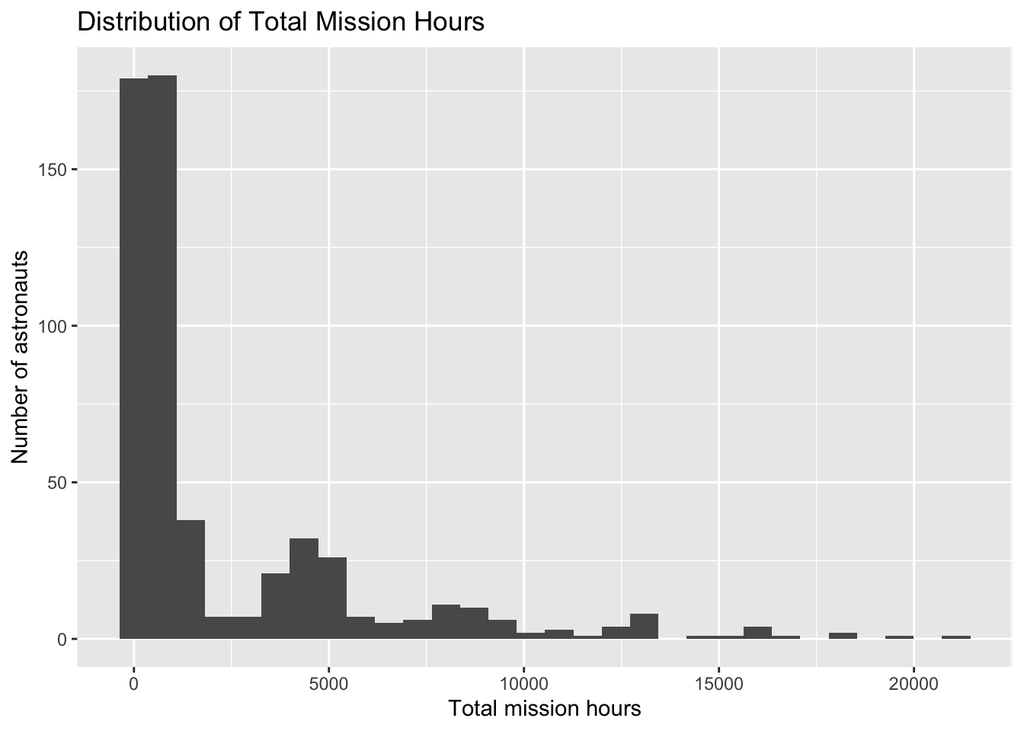

```r
ggplot(total_hours_df, aes(x = total_hrs_sum)) +
  geom_histogram() +
  labs(
    x = "Total mission hours",
    y = "Number of astronauts",
    title = "Distribution of Total Mission Hours"
  )
```

4. Provide a plot that shows the overall share of *civilian* astronauts by the year of mission!

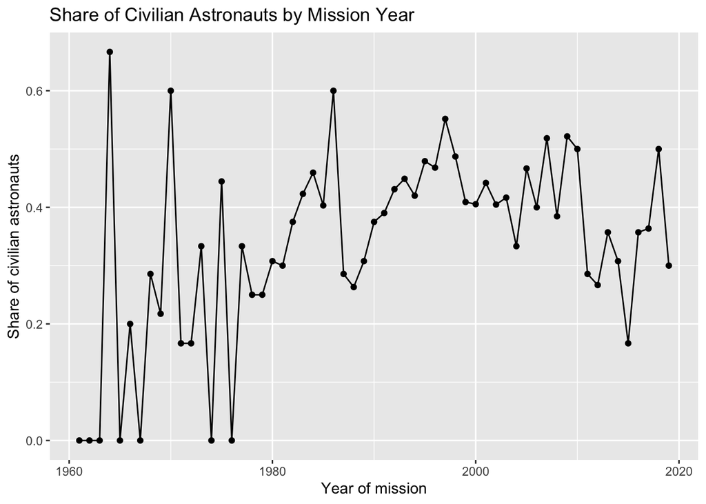

```r
share_civilians <- astronauts |>
  group_by(year_of_mission) |>
  summarise (
    share_civilians = mean(military_civilian == "civilian", na.rm = T)
  )
ggplot(share_civilians, aes(x = year_of_mission, y = share_civilians)) +
  geom_line() +
  geom_point() +
  labs(
    x = "Year of mission",
    y = "Share of civilian astronauts",
    title = "Share of Civilian Astronauts by Mission Year"
  )
```

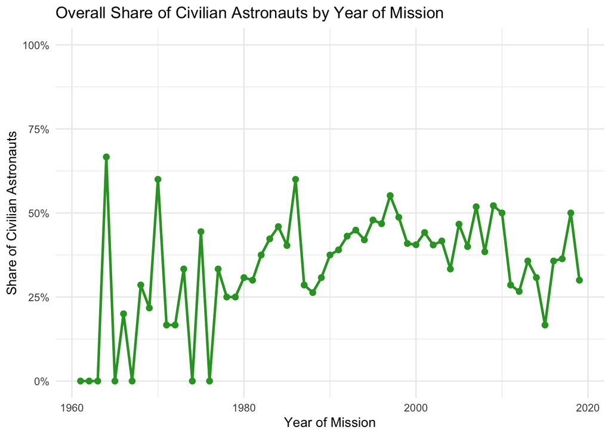

```r
share_civilians <- astronauts |>
  group_by(year_of_mission) |>
  summarise (
    share_civilians = mean(military_civilian == "civilian", na.rm = T)
  )


  ggplot(share_civilians, aes(x = year_of_mission, y = share_civilians)) +
  geom_line(color = "#2ca02c", linewidth = 1) +
  geom_point(color = "#2ca02c", size = 2) +
  scale_y_continuous(labels = scales::percent_format(), limits = c(0, 1)) +
  labs(
    title = "Overall Share of Civilian Astronauts by Year of Mission",
    x = "Year of Mission",
    y = "Share of Civilian Astronauts"
  ) +
  theme_minimal()
```